# bechdel_analysis

## Introduction

Data was taken from two data sets, one from BechdelTest.com and the other from TheNumbers.com. Data was collected from 1,794 movies released from 1970 to 2013 to observe the relationship between the presentation of women in a film and the film's profits. Gender bias in films is denoted by whether or not each film passes the Bechdel test. The Bechdel test states that if "there are at least two named women in the picture, they have a conversation with each other at some point, and that conversation isn’t about a male character," then the film is considered as passing.

```python
import pandas as pd

bechdel = pd.read_csv("movies.csv")
```

## Preprocessing

```python
bechdel.drop("test", axis=1, inplace=True)
bechdel.drop("imdb", axis=1, inplace=True)
bechdel.drop("title", axis=1, inplace=True)
bechdel.drop("code", axis=1, inplace=True)


bechdel.head()
```

|  | year | clean_test | binary | budget | domgross | intgross | budget_2013$ | domgross_2013$ | intgross_2013$ | period code | decade code |
| --- | --- | --- | --- | --- | --- | --- | --- | --- | --- | --- | --- |
| 0 | 2013 | notalk | FAIL | 13000000 | 25682380.0 | 42195766.0 | 13000000 | 25682380.0 | 42195766.0 | 1.0 | 1.0 |
| 1 | 2012 | ok | PASS | 45000000 | 13414714.0 | 40868994.0 | 45658735 | 13611086.0 | 41467257.0 | 1.0 | 1.0 |
| 2 | 2013 | notalk | FAIL | 20000000 | 53107035.0 | 158607035.0 | 20000000 | 53107035.0 | 158607035.0 | 1.0 | 1.0 |
| 3 | 2013 | notalk | FAIL | 61000000 | 75612460.0 | 132493015.0 | 61000000 | 75612460.0 | 132493015.0 | 1.0 | 1.0 |
| 4 | 2013 | men | FAIL | 40000000 | 95020213.0 | 95020213.0 | 40000000 | 95020213.0 | 95020213.0 | 1.0 | 1.0 |

2. Convert *binary* column to True/False dummy variables:

```python
bechdel = pd.get_dummies(bechdel, columns=['binary'], drop_first=True)

bechdel.head()
```

|  | year | clean_test | budget | domgross | intgross | budget_2013$ | domgross_2013$ | intgross_2013$ | period code | decade code | binary_PASS |
| --- | --- | --- | --- | --- | --- | --- | --- | --- | --- | --- | --- |
| 0 | 2013 | notalk | 13000000 | 25682380.0 | 42195766.0 | 13000000 | 25682380.0 | 42195766.0 | 1.0 | 1.0 | False |
| 1 | 2012 | ok | 45000000 | 13414714.0 | 40868994.0 | 45658735 | 13611086.0 | 41467257.0 | 1.0 | 1.0 | True |
| 2 | 2013 | notalk | 20000000 | 53107035.0 | 158607035.0 | 20000000 | 53107035.0 | 158607035.0 | 1.0 | 1.0 | False |
| 3 | 2013 | notalk | 61000000 | 75612460.0 | 132493015.0 | 61000000 | 75612460.0 | 132493015.0 | 1.0 | 1.0 | False |
| 4 | 2013 | men | 40000000 | 95020213.0 | 95020213.0 | 40000000 | 95020213.0 | 95020213.0 | 1.0 | 1.0 | False |

3. Detect and replace missing values:

```python
print("Number of missing values per column")
print(bechdel.isnull().sum())

replace_columns = [ "domgross", "intgross", "domgross_2013$", "intgross_2013$"]
bechdel[replace_columns] = bechdel[replace_columns].fillna(bechdel[replace_columns].mean())

bechdel.loc[(bechdel["decade code"].isnull()) & (bechdel["year"].between(1980, 1989)), "decade code"] = 4
bechdel.loc[(bechdel["decade code"].isnull()) & (bechdel["year"].between(1970, 1979)), "decade code"] = 5
bechdel.loc[(bechdel["period code"].isnull()) & (bechdel["year"].between(1985, 1989)), "period code"] = 6
bechdel.loc[(bechdel["period code"].isnull()) & (bechdel["year"].between(1980, 1984)), "period code"] = 7
bechdel.loc[(bechdel["period code"].isnull()) & (bechdel["year"].between(1975, 1979)), "period code"] = 8
bechdel.loc[(bechdel["period code"].isnull()) & (bechdel["year"].between(1970, 1974)), "period code"] = 9
```

```
Number of missing values per column
year                0
clean_test          0
budget              0
domgross           17
intgross           11
budget_2013$        0
domgross_2013$     18
intgross_2013$     11
period code       179
decade code       179
binary_PASS         0
dtype: int64
```

4. Outlier analysis:

```python
import numpy as np
outliers_count = None
quant_columns = ["budget", "domgross", "intgross", "budget_2013$", "domgross_2013$", "intgross_2013$"]

def count_outliers(x):
    Q25, Q75 = x.quantile([.25, .75])
    I = Q75 - Q25
    outliers = (x < Q25 - (1.5 * I)) | (x > Q75 + (1.5 * I))
    outliers_sum = outliers.sum()
    return outliers_sum

outliers_count = bechdel[quant_columns].apply(count_outliers)

outliers_count = outliers_count.rename(index=dict(zip(quant_columns, quant_columns)))
print("Number of outliers per quantitative column:")
print(outliers_count)
outliers_percentage = (outliers_count / len(bechdel)) * 100
outliers_percentage = outliers_percentage.rename(index=dict(zip(quant_columns, quant_columns)))
print("Percentage of outliers per quantitative column:")
print(outliers_percentage)
```

```
Number of outliers per quantitative column:
budget            121
domgross          117
intgross          146
budget_2013$       86
domgross_2013$    128
intgross_2013$    164
dtype: int64
Percentage of outliers per quantitative column:
budget            6.744705
domgross          6.521739
intgross          8.138239
budget_2013$      4.793757
domgross_2013$    7.134894
intgross_2013$    9.141583
dtype: float64
```

```python
def is_outlier(x):
    Q25, Q75 = x.quantile([.25, .75])
    I = Q75 - Q25
    return (x < Q25 - (1.5 * I)) | (x > Q75 + (1.5 * I))

outliers = bechdel[quant_columns].apply(is_outlier)
outliers_counts = bechdel.loc[outliers.any(axis=1)].value_counts()

cleaned = bechdel[~outliers]

print( "Means with outliers:" )
print( bechdel[quant_columns].mean() )
print( "\nMeans without outliers:" )
print( cleaned[quant_columns].mean() )
```

```
Means with outliers:
budget            4.482646e+07
domgross          6.913205e+07
intgross          1.503857e+08
budget_2013$      5.546461e+07
domgross_2013$    9.517478e+07
intgross_2013$    1.978380e+08
dtype: float64

Means without outliers:
budget            3.508815e+07
domgross          5.310973e+07
intgross          1.010856e+08
budget_2013$      4.731704e+07
domgross_2013$    6.891667e+07
intgross_2013$    1.273543e+08
dtype: float64
```

Each quantitative column has around 6-9% of its entries as outliers, except for *budget_2013$*, which has only about 4% as outliers. The two series above show that the outliers skew the data in every column to the right. Therefore, we will use the median for a better representation of the center of the data.

## Summary Data Analysis

We can see from the graph below that most data collected came from movies in the 21st century.

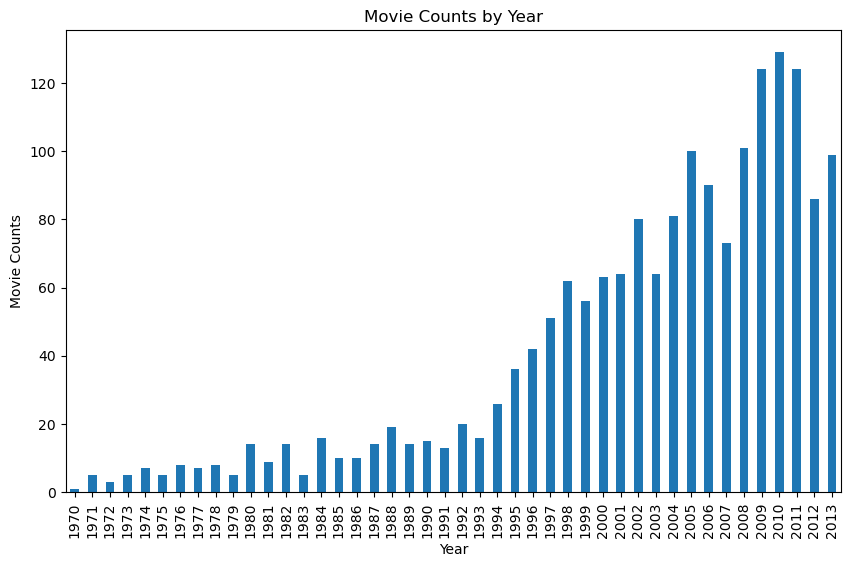

```python
import matplotlib.pyplot as plt

movie_counts_by_year = bechdel.groupby("year").size()
sorted_movie_counts = movie_counts_by_year.sort_index()

sorted_movie_counts.plot(kind='bar', figsize=(10, 6))
plt.xlabel('Year')
plt.ylabel('Movie Counts')
plt.title('Movie Counts by Year')
plt.show()
```

The column *binary_pass* holds boolean values that represent whether or not a movie passes the Bechdel Test. The graph below shows us that out of the movies recorded , almost 200 more movies are not passing rather than passing.

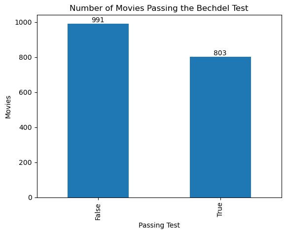

```python
pass_counts = bechdel['binary_PASS'].value_counts()
ax = pass_counts.plot(kind='bar')
plt.xlabel('Passing Test')
plt.ylabel('Movies')
plt.title('Number of Movies Passing the Bechdel Test')

for i, count in enumerate(pass_counts):
    ax.text(i, count, str(count), ha='center', va='bottom')

plt.show()
```

There are three columns in the data that represent periods of time: *year*, *period code*, and *decade code*. *period code* represents five-year intervals starting with 1-2 (2010-2015) and ending at 8-9 (1970-1975). *decade code* represents ten-year intervals, or decades, starting at 1.0-2.0 (2010-2020) and ending at 5.0-6.0 (1970-1980).

The three line plots below show the percentage of movies passing the Bechdel Test when grouped by each of these columns. The first graph is more sensitive to outliers, which makes it difficult to see a trend. However, once we break down the data by periods and then decades, we can see a steady increase in percentages over the years. The decade with the most increase in test passes is 3.0-4.0, or the 1990s. After 2010, there is a slight decrease, but over 40% of movies are still passing.

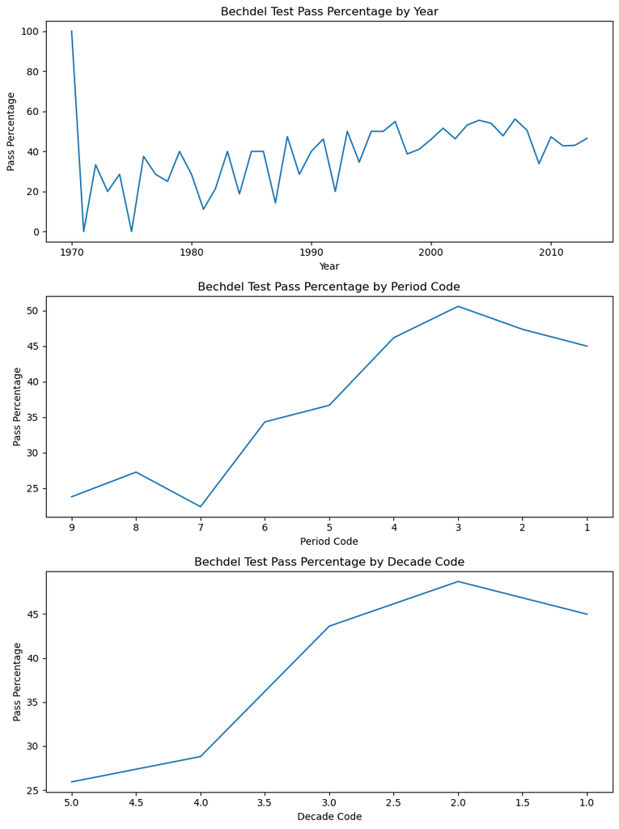

```python
import matplotlib.pyplot as plt

fig, axes = plt.subplots(3, 1, figsize=(9, 12))

pass_percentage_by_year = (bechdel.groupby("year")["binary_PASS"].sum() / bechdel.groupby("year")["binary_PASS"].count()) * 100
pass_percentage_by_year.plot(kind='line', ax=axes[0])
axes[0].set_xlabel('Year')
axes[0].set_ylabel('Pass Percentage')
axes[0].set_title('Bechdel Test Pass Percentage by Year')

pass_percentage_by_period = (bechdel.groupby("period code")["binary_PASS"].sum() / bechdel.groupby("period code")["binary_PASS"].count()) * 100
pass_percentage_by_period.plot(kind='line', ax=axes[1])
axes[1].set_xlabel('Period Code')
axes[1].set_ylabel('Pass Percentage')
axes[1].set_title('Bechdel Test Pass Percentage by Period Code')
axes[1].invert_xaxis()  # Reverse x-axis

pass_percentage_by_decade = (bechdel.groupby("decade code")["binary_PASS"].sum() / bechdel.groupby("decade code")["binary_PASS"].count()) * 100
pass_percentage_by_decade.plot(kind='line', ax=axes[2])
axes[2].set_xlabel('Decade Code')
axes[2].set_ylabel('Pass Percentage')
axes[2].set_title('Bechdel Test Pass Percentage by Decade Code')
axes[2].invert_xaxis()  # Reverse x-axis

plt.tight_layout()
plt.show()
```

The column *budget* represents the budget in dollars for a movie, and the column *budget_2013$* represents the same budget adjusted for inflation that has occured by the year 2013. The summary statistics for *budget* and *budget_2013$* are shown below. From the coefficients of variation and difference between maximum and minimum values, we can see there is a lot of variation in both columns.

```python
import numpy as np
print(bechdel[['budget', 'budget_2013$']].describe())
budget = bechdel['budget']
budget_2013 = bechdel['budget_2013$']

cv_budget = np.std(budget) / np.mean(budget)
cv_budget_2013 = np.std(budget_2013) / np.mean(budget_2013)
print("\nThe coefficient of variation for budget is:")
print(cv_budget)
print("The coefficient of variation for budget_2013$ is:")
print(cv_budget_2013)
```

```
             budget  budget_2013$
count  1.794000e+03  1.794000e+03
mean   4.482646e+07  5.546461e+07
std    4.818603e+07  5.491864e+07
min    7.000000e+03  8.632000e+03
25%    1.200000e+07  1.606892e+07
50%    2.800000e+07  3.699579e+07
75%    6.000000e+07  7.833790e+07
max    4.250000e+08  4.614359e+08

The coefficient of variation for budget is:
1.0746463509357185
The coefficient of variation for budget_2013$ is:
0.9898803723687786
```

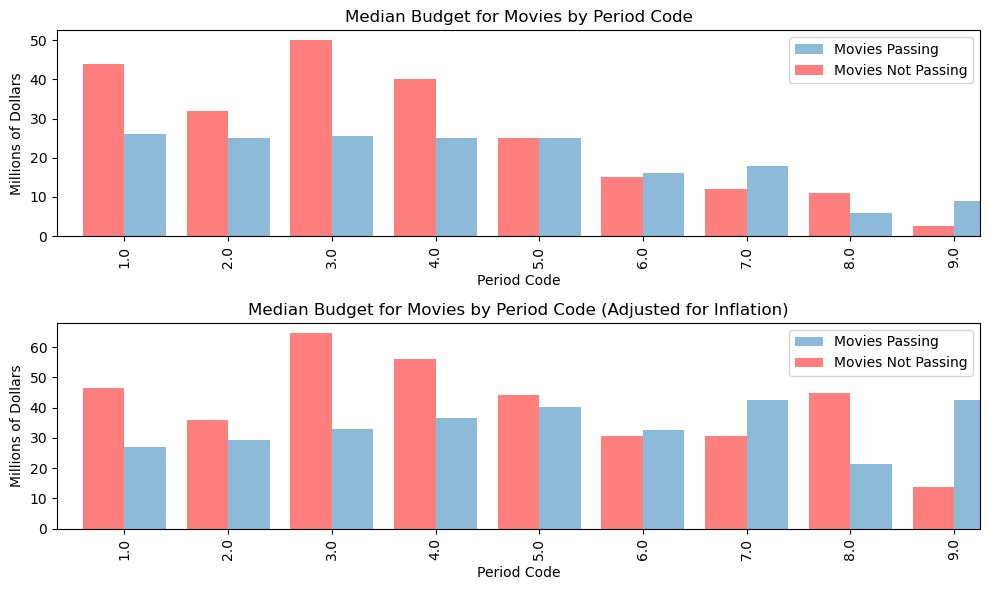

```python
pass_by_period_budget = bechdel[bechdel['binary_PASS'] == 1].groupby('period code')['budget'].median() / 1000000
not_pass_by_period_budget = bechdel[bechdel['binary_PASS'] == 0].groupby('period code')['budget'].median() / 1000000

pass_by_period_budget_2013 = bechdel[bechdel['binary_PASS'] == 1].groupby('period code')['budget_2013$'].median() / 1000000
not_pass_by_period_budget_2013 = bechdel[bechdel['binary_PASS'] == 0].groupby('period code')['budget_2013$'].median() / 1000000

fig, axes = plt.subplots(2, 1, figsize=(10, 6))

pass_by_period_budget.plot(kind='bar', ax=axes[0], label='Movies Passing', alpha=0.5, position=0, width=0.4)
not_pass_by_period_budget.plot(kind='bar', ax=axes[0], color='red', label='Movies Not Passing', alpha=0.5, position=1, width=0.4)

axes[0].set_xlabel('Period Code')
axes[0].set_ylabel('Millions of Dollars')
axes[0].set_title('Median Budget for Movies by Period Code')
axes[0].legend()

pass_by_period_budget_2013.plot(kind='bar', ax=axes[1], label='Movies Passing', alpha=0.5, position=0, width=0.4)
not_pass_by_period_budget_2013.plot(kind='bar', ax=axes[1], color='red', label='Movies Not Passing', alpha=0.5, position=1, width=0.4)

axes[1].set_xlabel('Period Code')
axes[1].set_ylabel('Millions of Dollars')
axes[1].set_title('Median Budget for Movies by Period Code (Adjusted for Inflation)')
axes[1].legend()

plt.tight_layout()
plt.show()
```

The column *domgross* represents the domestic gross in dollars for a movie, and the column *domgross_2013$* represents the same domestic gross adjusted for inflation that has occured by the year 2013. The summary statistics for *domgross* and *domgross_2013$* are shown below. From the coefficients of variation and difference between maximum and minimum values, we can see there is a lot of variation in both columns, and more variation than the columns representing budget.

```python
import numpy as np
print(bechdel[['domgross', 'domgross_2013$']].describe())
domgross = bechdel['domgross']
domgross_2013 = bechdel['domgross_2013$']

cv_domgross = np.std(domgross) / np.mean(domgross)
cv_domgross_2013 = np.std(domgross_2013) / np.mean(domgross_2013)
print("\nThe coefficient of variation for domgross is:")
print(cv_domgross)
print("The coefficient of variation for domgross_2013$ is:")
print(cv_domgross_2013)
```

```
           domgross  domgross_2013$
count  1.794000e+03    1.794000e+03
mean   6.913205e+07    9.517478e+07
std    7.998541e+07    1.253315e+08
min    0.000000e+00    8.990000e+02
25%    1.667140e+07    2.067093e+07
50%    4.302788e+07    5.648654e+07
75%    9.216850e+07    1.207983e+08
max    7.605076e+08    1.771683e+09

The coefficient of variation for domgross is:
1.1566721164104834
The coefficient of variation for domgross_2013$ is:
1.3164887594090666
```

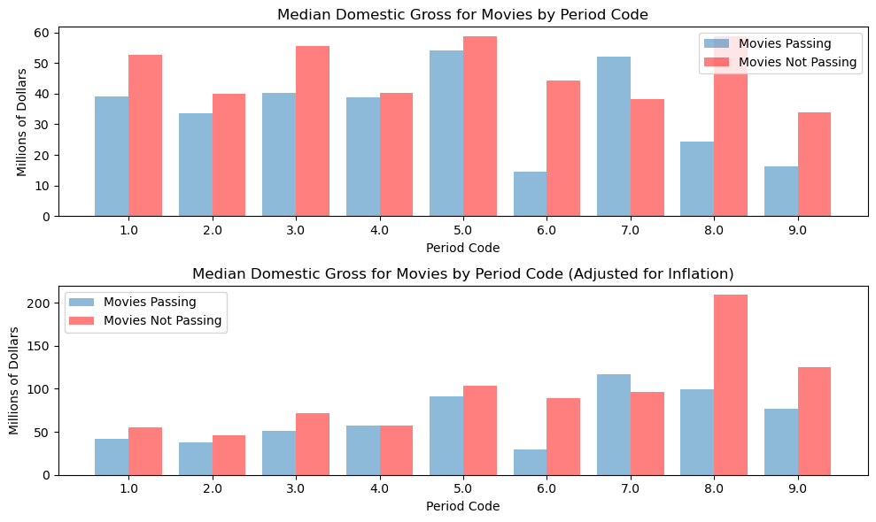

```python
pass_by_period_domgross = bechdel[bechdel['binary_PASS'] == 1].groupby('period code')['domgross'].median()
not_pass_by_period_domgross = bechdel[bechdel['binary_PASS'] == 0].groupby('period code')['domgross'].median()

pass_by_period_domgross_2013 = bechdel[bechdel['binary_PASS'] == 1].groupby('period code')['domgross_2013$'].median()
not_pass_by_period_domgross_2013 = bechdel[bechdel['binary_PASS'] == 0].groupby('period code')['domgross_2013$'].median()

pass_by_period_domgross = bechdel[bechdel['binary_PASS'] == 1].groupby('period code')['domgross'].median() / 1000000
not_pass_by_period_domgross = bechdel[bechdel['binary_PASS'] == 0].groupby('period code')['domgross'].median() / 1000000

pass_by_period_domgross_2013 = bechdel[bechdel['binary_PASS'] == 1].groupby('period code')['domgross_2013$'].median() / 1000000
not_pass_by_period_domgross_2013 = bechdel[bechdel['binary_PASS'] == 0].groupby('period code')['domgross_2013$'].median() / 1000000

fig, axes = plt.subplots(2, 1, figsize=(10, 6))

width = 0.4
x = np.arange(len(pass_by_period_domgross))

pass_bars = axes[0].bar(x - width/2, pass_by_period_domgross, width, label='Movies Passing', alpha=0.5)
not_pass_bars = axes[0].bar(x + width/2, not_pass_by_period_domgross, width, color='red', label='Movies Not Passing', alpha=0.5)

axes[0].set_xlabel('Period Code')
axes[0].set_ylabel('Millions of Dollars')
axes[0].set_title('Median Domestic Gross for Movies by Period Code')
axes[0].set_xticks(x)
axes[0].set_xticklabels(pass_by_period_domgross.index)
axes[0].legend()

pass_bars_2013 = axes[1].bar(x - width/2, pass_by_period_domgross_2013, width, label='Movies Passing', alpha=0.5)
not_pass_bars_2013 = axes[1].bar(x + width/2, not_pass_by_period_domgross_2013, width, color='red', label='Movies Not Passing', alpha=0.5)

axes[1].set_xlabel('Period Code')
axes[1].set_ylabel('Millions of Dollars')
axes[1].set_title('Median Domestic Gross for Movies by Period Code (Adjusted for Inflation)')
axes[1].set_xticks(x)
axes[1].set_xticklabels(pass_by_period_domgross_2013.index)
axes[1].legend()

# Adjust the layout to create space between the bars
fig.tight_layout()

plt.show()
```

The column *intgross* represents the international gross in dollars for a movie, and the column *intgross_2013$* represents the same international gross adjusted for inflation that has occured by the year 2013. The summary statistics for *intgross* and *intgross_2013$* are shown below. From the coefficients of variation and difference between maximum and minimum values, we can see there is a lot of variation in both columns.

```python
import numpy as np
print(bechdel[['intgross', 'intgross_2013$']].describe())
intgross = bechdel['intgross']
intgross_2013 = bechdel['intgross_2013$']

cv_intgross = np.std(intgross) / np.mean(intgross)
cv_intgross_2013 = np.std(intgross_2013) / np.mean(intgross_2013)
print("\nThe coefficient of variation for intgross is:")
print(cv_intgross)
print("The coefficient of variation for intgross_2013$ is:")
print(cv_intgross_2013)
```

```
           intgross  intgross_2013$
count  1.794000e+03    1.794000e+03
mean   1.503857e+08    1.978380e+08
std    2.096891e+08    2.826370e+08
min    8.280000e+02    8.990000e+02
25%    2.632845e+07    3.357618e+07
50%    7.751440e+07    9.722534e+07
75%    1.880873e+08    2.406311e+08
max    2.783919e+09    3.171931e+09

The coefficient of variation for intgross is:
1.3939531818127984
The coefficient of variation for intgross_2013$ is:
1.4282301257903052
```

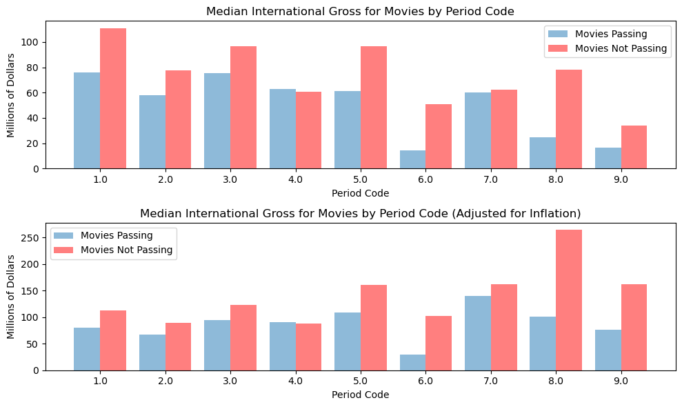

```python
pass_by_period_intgross = bechdel[bechdel['binary_PASS'] == 1].groupby('period code')['intgross'].median() / 1000000
not_pass_by_period_intgross = bechdel[bechdel['binary_PASS'] == 0].groupby('period code')['intgross'].median() / 1000000

pass_by_period_intgross_2013 = bechdel[bechdel['binary_PASS'] == 1].groupby('period code')['intgross_2013$'].median() / 1000000
not_pass_by_period_intgross_2013 = bechdel[bechdel['binary_PASS'] == 0].groupby('period code')['intgross_2013$'].median() / 1000000

fig, axes = plt.subplots(2, 1, figsize=(10, 6))

width = 0.4
x = np.arange(len(pass_by_period_intgross))

pass_bars = axes[0].bar(x - width/2, pass_by_period_intgross, width, label='Movies Passing', alpha=0.5)
not_pass_bars = axes[0].bar(x + width/2, not_pass_by_period_intgross, width, color='red', label='Movies Not Passing', alpha=0.5)

axes[0].set_xlabel('Period Code')
axes[0].set_ylabel('Millions of Dollars')
axes[0].set_title('Median International Gross for Movies by Period Code')
axes[0].set_xticks(x)
axes[0].set_xticklabels(pass_by_period_intgross.index)
axes[0].legend()

pass_bars_2013 = axes[1].bar(x - width/2, pass_by_period_intgross_2013, width, label='Movies Passing', alpha=0.5)
not_pass_bars_2013 = axes[1].bar(x + width/2, not_pass_by_period_intgross_2013, width, color='red', label='Movies Not Passing', alpha=0.5)

axes[1].set_xlabel('Period Code')
axes[1].set_ylabel('Millions of Dollars')
axes[1].set_title('Median International Gross for Movies by Period Code (Adjusted for Inflation)')
axes[1].set_xticks(x)
axes[1].set_xticklabels(pass_by_period_intgross_2013.index)
axes[1].legend()

fig.tight_layout()

plt.show()
```

The bar graph below compares median budget and domestic and international gross by different components of the Bechdel test. All five groups of bars look very similar. Therefore, the median budget, domestic gross, and international gross of movies tend to be close, regardless of what component(s) of the Bechdel test the movies are passing. Although all components have very close results, the movies with the highest budget and grosses include women, but the women do not talk.

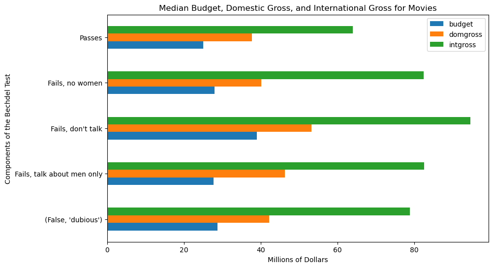

```python
import matplotlib.pyplot as plt

quant_columns = ["budget", "domgross", "intgross"]

grouped_data = bechdel.groupby(['binary_PASS', 'clean_test'])[quant_columns].median()

labels = {
    (True, 'ok'): 'Passes',
    (False, 'nowomen'): 'Fails, no women',
    (False, 'notalk'): "Fails, don't talk",
    (False, 'men'): 'Fails, talk about men only'
}

grouped_data = grouped_data / 1000000

grouped_data.plot(kind='barh', figsize=(10, 6))
plt.xlabel('Millions of Dollars')
plt.ylabel('Components of the Bechdel Test')
plt.title('Median Budget, Domestic Gross, and International Gross for Movies')
plt.legend()

plt.yticks(range(len(grouped_data.index)), [labels.get(label, label) for label in grouped_data.index])

plt.show()
```

The correlation graphs below show the relationship between domestic and international gross (adjusted for inflation). Each point is colored by whether or not it passes the Bechdel test. There is a clear positive correlation between both of these columns, with an even mix of blue and orange dots. Therefore, the correlation between domestic and international gross is positive, regardless of whether or not the movies pass or do not pass the test.

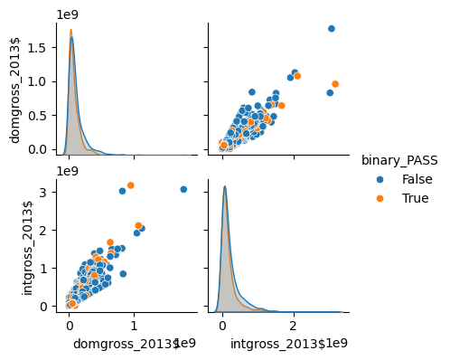

```python
import seaborn as sns

columns = ["domgross_2013$", "intgross_2013$"]
quantitative_columns = bechdel[columns + ["binary_PASS"]]

sns.pairplot(data=quantitative_columns, vars=columns, hue="binary_PASS", height=2, diag_kind="kde")
```

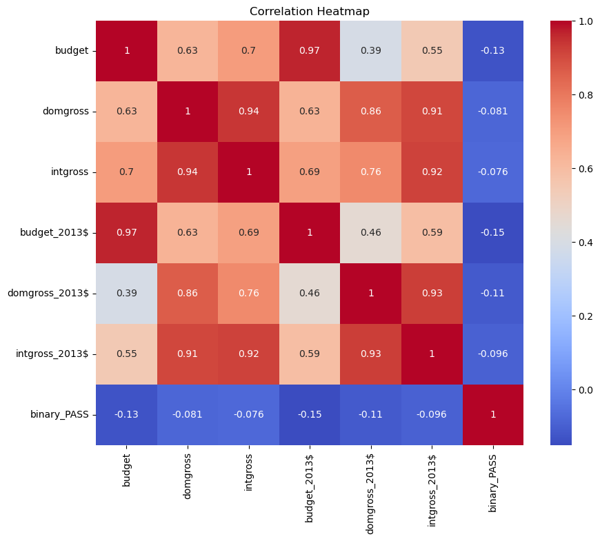

```python
import seaborn as sns
import matplotlib.pyplot as plt

quant_columns = ["budget", "domgross", "intgross", "budget_2013$", "domgross_2013$", "intgross_2013$"]
correlation_matrix = bechdel[quant_columns + ["binary_PASS"]].corr()

plt.figure(figsize=(10, 8))
sns.heatmap(correlation_matrix, annot=True, cmap="coolwarm")
plt.title("Correlation Heatmap")
plt.show()
```

## Discussion

Question 1:

Do budget, domestic gross, and international gross (adjusted and not adjusted for inflation) of movies predict the presence of women in films the following year?

Question 2:

Can a movie's international gross be predicted by its budget, domestic gross (adjusted and not adjusted for inflation), and whether or not the movie passes the Bechdel test?

In order to address both of these questions, I think it is important to collect additional data from movies over the years 1970-2000 as well as new data from movies since 2014 to now. The lack of data from older periods makes it more difficult to observe significant trends and correlations over the years. With a bigger sample size of movies, we will be able to form a better understanding of how movies passing the Bechdel test perform from year to year.